# Data Products Assignment Week 4

P R Rakesh Sharma

January 12, 2019

# Data Product - Understanding Diamond Prices with carat

This application uses the following R features:

- shiny web application architecture with ui and server files
- diamond data set
- linear model for prediction of Price with carat

# User documentation

This application is used by the end-user as follows:

This app enables you to display various subsets of the diamond data set and check the influence on the carat/price relationship in the data. A basic linear model relationship is displayed based on the selected subset of the data and price prediction is possible via selecting the respective filter variables and a carat value.

Furthermore it is possible to remove the filter and display the whole dataset by pressing the button SHOW ALL. To go back the the filtered view, press FILTER MODE and all your filters are reapplied. Per default, filter mode is active.

Finally a data summary is displayed and a price can be predicted by selecting a subset of the data and choosing a carat value. Simply choose cut, color, clarity and carat as you see fit and a value is predicted based on your selection.

The application has been published at [link] https://rakeshsharma14.shinyapps.io/Assignment_4/

# Source Code for the App

The ui.r and server.r files contains the code for this app. The code has been published to the github and can be accessed at [link] https://github.com/rakeshsharma14/Data-Products

# Price Prediction Plot

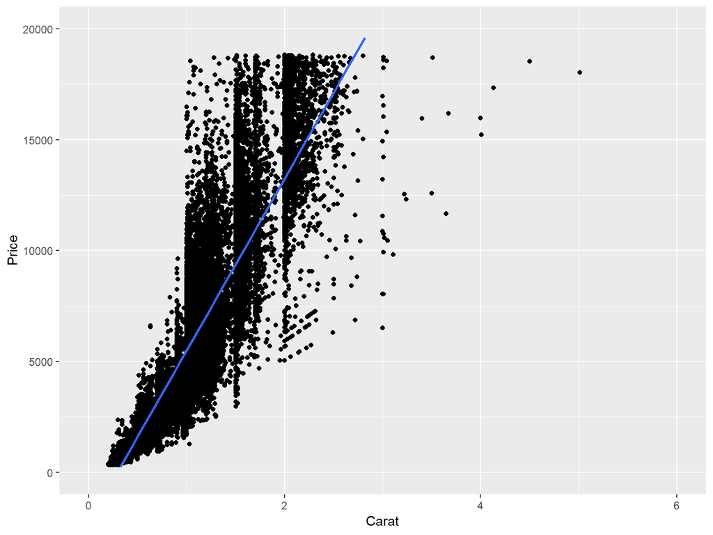